# 207.1. Timeseries values

For the Rubin Science Platform at data.lsst.cloud.  
Data Release: [Data Preview 2](https://dp2.lsst.io/)  
Container Size: Large  
LSST Science Pipelines version: r30.0.10  
Last verified to run: 2026-07-24  
Repository: github.com/lsst/tutorial-notebooks  
DOI: 10.11578/rubin/dc.20250909.20

**Learning objective:** Understand how the values of the timeseries features in the `DiaObject` table are derived.

**LSST data products:** `DiaObject`, `DiaSource`

**Credit:** Originally developed by the Rubin Community Science team. Please consider acknowledging them if this notebook is used for the preparation of journal articles, software releases, or other notebooks.

**Get Support:** Everyone is encouraged to ask questions or raise issues in the [Support Category](https://community.lsst.org/c/support) of the Rubin Community Forum. Rubin staff will respond to all questions posted there.

## 1. Introduction

A set of timeseries features, also called variability characterization parameters, are computed for all rows of the `DiaObject` table using flux measurements from the `DiaSource` table.

This tutorial serves as a reference for interpreting the timeseries features of a given `DiaObject`. For each feature, this tutorial provides descriptions and equations, code to recalculate the parameter using the `DiaSource` flux measurements, and an illustration of what the feature indicates about the lightcurve.

A known pulsating variable star is used as the example `DiaObject`. It is important to note that although all timeseries features are *calculated* for all `DiaObject`s, they are not all *appropriate* for the interpretation of all `DiaObject`s. For example, a linear slope is calculated for all `DiaObject`s, but many types of transients and variables are not expected to exhibit a linear slope.

**Why are there fewer features for DP2 than DP1?** For DP2, the Data Release pipeline's calculation of timeseries features was adjusted to match the Prompt pipeline's codes for timeseries features. The intent is now that *both* pipelines will match, going forward, and build up the number of timeseries features.

For future data releases, additional timeseries features are likely to be included, as discussed in Data Management Tech Note 118 [Review of Timeseries Features (DMTN-118)](https://dmtn-118.lsst.io/).

**Related tutorials:** The 200-level tutorials on the `DiaObject` and `DiaSource` tables, and the other tutorial in the 207 series on timeseries features.

### 1.1. Features summary

The timeseries features are calculated based on the fluxes in the `DiaSource` table, and this table only includes visits (observations) for which there was a SNR $>5$ detection in the difference image. For example, for periodic variables, visits for which the star had a brightness similar to its brightness in the template image - and thus very little flux in the difference image - do not contribute to the timeseries features' values.

The following parameters are calculated per filter (`<f>`), using the difference image photometry (`psfFlux`) column from the `diaSources` that are associated with a given `DiaObject`.

- `<f>_psfFluxNdata` : The number of associated `diaSources`.
- `<f>_psfFluxErrMean` : Mean of the `diaSource` PSF flux errors.
- `<f>_psfFluxMin`, `Max` : Minimum and maximum `diaSource` PSF flux.
- `<f>_psfFluxMean`, `MeanErr` : Inverse variance weighted mean of `diaSource` PSF flux, and its standard error.
- `<f>_psfFluxSigma` : Standard deviation of the distribution of `<f>_psfFlux`.
- `<f>_psfFluxMaxSlope` : Maximum ratio of time ordered $\Delta f / \Delta t$.

The following parameters are calculated per filter with forced photometry on the science image (also called the direct or visit image) at the `diaSource` positions (the `scienceFlux` column).

- `<f>_scienceFluxMean` : Weighted mean of the PSF flux (forced photometered on the visit image).
- `<f>_scienceFluxMeanErr` : Standard error on `<f>_scienceFluxMean`.

Although the `scienceFlux` features are forced photometry, because they are from the `DiaSource` table they only include images in which the astrophysical object was detected with SNR$>5$ in the difference image. These timeseries features do not use the forced photometry that is performed at the location of all `diaObjects` in all visit and difference images, which is stored in the `ForcedSourceOnDiaObject` table.

### 1.2. Import packages

From the `lsst` package, import modules for accessing the Table Access Protocol (TAP) service and making colorblind-friedly plots.

```python
import numpy as np
import matplotlib.pyplot as plt
from lsst.rsp import RSPDiscovery
from lsst.utils.plotting import (get_multiband_plot_colors,
                                 get_multiband_plot_symbols,
                                 get_multiband_plot_linestyles)
```

### 1.3. Define parameters

Define colors, symbols, and linestyles to represent the six LSST filters, $ugrizy$.

```python
f_col = get_multiband_plot_colors()
f_name = f_col.keys()
f_sym = get_multiband_plot_symbols()
f_lin = get_multiband_plot_linestyles()
```

Get an instance of the TAP service.

```python
discovery = RSPDiscovery("dp2")
tap_service = discovery.get_tap_client()
```

For this tutorial, use only the $g$- and $r$-band to illustrate the timeseries features.

```python
use_filters = ['g', 'r']
```

## 2. Retrieve data for a known variable star

The first step to obtain light curve data is to define the coordinates (ra and dec) of a known RR Lyrae variable star captured in DP2: Gaia DR3 [6005347144427786624](https://gaia.aip.de/serve/references/source_id/6005347144427786624?job_id=9a24e576-30d9-4d93-9c52-7dd39ba85f86).

This star is classified in Gaia DR3's `vari_rrlyrae` table as an RRab-type variable with a period of 0.5180638410804721 days.

```python
star_diaObjectId = 743582465276248313
```

### 2.1. The diaObject record

Retrieve all of the $g$- and $r$-band timeseries features from the `DiaObject` table. Create a comma-separated list of columns to retrieve from the `DiaObject` table. Include the $g$- and $r$-band timeseries features, plus the `nDiaSources` column.

```python
query = "SELECT column_name " \
        "FROM tap_schema.columns " \
        "WHERE table_name = 'dp2.DiaObject'"
results = tap_service.search(query).to_table()

columns_list = ''
for filt in use_filters:
    for name in results['column_name']:
        if name.find(filt + '_') == 0:
            columns_list += name + ', '
columns_list += 'nDiaSources'

del query, results
```

Define a query to retrieve all columns in the list from the `DiaObject` table for the row corresponding to the variable star, and submit the query to the TAP service.

```python
query = """SELECT {} FROM dp2.DiaObject WHERE diaObjectId = {}
        """.format(columns_list, star_diaObjectId)

job = tap_service.submit_job(query)
job.run()
job.wait(phases=['COMPLETED', 'ERROR'])
print('Job phase is', job.phase)
if job.phase == 'ERROR':
    job.raise_if_error()

del query
```

```
Job phase is COMPLETED
```

Retrieve the results from the TAP service as an `astropy` table named `star_diaObject`.

```python
assert job.phase == 'COMPLETED'
star_diaObject = job.fetch_result().to_table()
assert len(star_diaObject) == 1
```

Option to view `star_diaObject`.

```python
# star_diaObject
```

```python
job.delete()
```

### 2.2. The diaSource records

In general, for scientific analyses of lightcurves it is recommended to use the *forced* flux measurements in the `ForcedSourceOnDiaObject` table. However, because the timeseries features in the `DiaObject` table are calculated using the detection (unforced) flux measurements from the `DiaSource` table, this tutorial also uses them. The key difference to be aware of is that the `DiaSource` table only contains flux measurements for visits in which the `diaObject` was detected with SNR$\geq5$ in the difference image, whereas the `ForcedSourceOnDiaObject` table contains forced flux measurements for *all* visits.

Define a query to retrieve the $g$- and $r$-band difference-image (`psfFlux`) and direct-image (`scienceFlux`) measurements, the flux errors, and the exposure time midpoint Modified Julian Date (`midpointMjdTai`) from the `DiaSource` table.

```python
query = """SELECT psfFlux, psfFluxErr, scienceFlux, scienceFluxErr, band, midpointMjdTai
        FROM dp2.DiaSource
        WHERE (band = '{}' OR band = '{}')
        AND diaObjectId = {}
        """.format(str(use_filters[0]), str(use_filters[1]), str(star_diaObjectId))

job = tap_service.submit_job(query)
job.run()
job.wait(phases=['COMPLETED', 'ERROR'])
print('Job phase is', job.phase)
if job.phase == 'ERROR':
    job.raise_if_error()

del query
```

```
Job phase is COMPLETED
```

Retrieve the results from the TAP service as an `astropy` table named `star_diaSources`.

```python
assert job.phase == 'COMPLETED'
star_diaSources = job.fetch_result().to_table()
print(len(star_diaSources))
```

```
352
```

```python
job.delete()
```

Visualize the measured fluxes from the `DiaSource` table as a lightcurve.

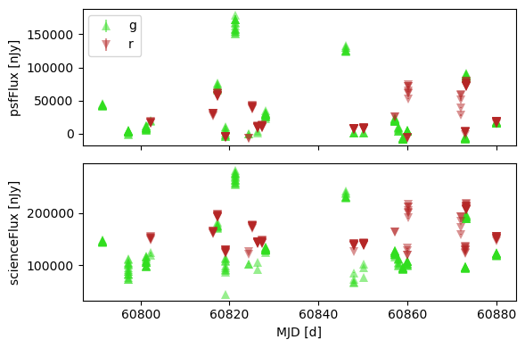

```python
fig, (ax1, ax2) = plt.subplots(2, 1, figsize=(6, 4), sharex=True)
for filt in use_filters:
    tx = np.where(star_diaSources['band'] == filt)[0]
    ax1.errorbar(star_diaSources[tx]['midpointMjdTai'], star_diaSources[tx]['psfFlux'],
                 yerr=star_diaSources[tx]['psfFluxErr'], fmt=f_sym[filt], ms=7,
                 alpha=0.5, mew=0, color=f_col[filt], label=filt)
    ax2.errorbar(star_diaSources[tx]['midpointMjdTai'], star_diaSources[tx]['scienceFlux'],
                 yerr=star_diaSources[tx]['scienceFluxErr'], fmt=f_sym[filt], ms=7,
                 alpha=0.5, mew=0, color=f_col[filt], label=filt)
    del tx
ax1.set_ylabel('psfFlux [nJy]')
ax2.set_ylabel('scienceFlux [nJy]')
ax2.set_xlabel('MJD [d]')
ax1.legend(loc='upper left')
plt.tight_layout()
plt.show()
```

> **Figure 1**: The `psfFlux` (difference image flux; top) and `scienceFlux` (direct image flux; bottom) for all visits in which the star was detected with SNR>5 in the difference image, versus the MJD of the visit, for the $g$- and $r$-bands only. The errors bars on the flux are, for most data points, relatively too small to be seen.

## 3. Timeseries features

The following subsections demonstrate how each of the timeseries features in the `DiaObject` table are derived by recalculating them from the observations in the `DiaSource` table. For scientific analyses it is not necessary to recalculate these features; this tutorial does it only as a demonstration.

### 3.1. Ndata

The `<f>_psfFluxNdata` column is the number of rows in the `DiaSource` table that are associated with a given `diaObject`, for a given filter. In other words, this is the number of difference-image detections of a given `diaObject` in a given band.

Recalculate the `<f>_psfFluxNdata` column using the `DiaSource` table, and confirm it matches the `DiaObject` table.

```python
for f, filt in enumerate(use_filters):
    diao_ndata = int(star_diaObject[filt+'_psfFluxNdata'])
    tx = np.where(star_diaSources['band'] == filt)[0]
    dias_ndata = len(tx)
    print(filt + '-band   diaObject    diaSource')
    print('Ndata   %10i   %10i' % (diao_ndata, dias_ndata))
    if f == 0:
        print(' ')
    del diao_ndata, tx, dias_ndata
```

```
g-band   diaObject    diaSource
Ndata          204          204

r-band   diaObject    diaSource
Ndata          148          148
```

### 3.2. ErrMean

The `<f>_psfFluxErrMean` column is the unweighted average of the `psfFluxErr` values: $\frac{1}{N}\sum{e_{f}}$, where $e_f$ is the flux error (`psfFluxErr`) and $N$ is the number of flux measurements.

Recalculate the `<f>_psfFluxErrMean` column using the `DiaSource` table, and confirm it matches the `DiaObject` table.

```python
for f, filt in enumerate(use_filters):
    diao_emean = float(star_diaObject[filt + '_psfFluxErrMean'])
    tx = np.where(star_diaSources['band'] == filt)[0]
    dias_emean = np.sum(star_diaSources['psfFluxErr'][tx])/len(tx)
    print(filt + '-band    diaObject    diaSource')
    print('ErrMean  %10.0f   %10.0f ' % (diao_emean, dias_emean))
    if f == 0:
        print(' ')
    del diao_emean, tx, dias_emean
```

```
g-band    diaObject    diaSource
ErrMean         364          364

r-band    diaObject    diaSource
ErrMean         527          527
```

### 3.3. Min, Max

The `<f>_psfFluxMin` and `Max` values are the lowest and highest values of the `psfFlux` column (difference-image fluxes) for the `diaObject`.

Recalculate the `<f>_psfFluxMin` and `Max` columns using the `DiaSource` table, and confirm they match the `DiaObject` table.

```python
for f, filt in enumerate(use_filters):
    diao_min = float(star_diaObject[filt + '_psfFluxMin'])
    diao_max = float(star_diaObject[filt + '_psfFluxMax'])
    tx = np.where(star_diaSources['band'] == filt)[0]
    dias_min = np.min(star_diaSources['psfFlux'][tx])
    dias_max = np.max(star_diaSources['psfFlux'][tx])
    print(filt + '-band    diaObject    diaSource')
    print('Min      %10.0f   %10.0f ' % (diao_min, dias_min))
    print('Max      %10.0f   %10.0f ' % (diao_max, dias_max))
    if f == 0:
        print(' ')
    del diao_min, diao_max, tx, dias_min, dias_max
```

```
g-band    diaObject    diaSource
Min           -8579        -8579
Max          178302       178302

r-band    diaObject    diaSource
Min           -7607        -7607
Max           79400        79400
```

### 3.4. Mean, MeanErr

The `<f>_psfFluxMean` is the *weighted* mean of the measured difference-image fluxes: $\bar{f_w} = \frac{\sum{f\times w}}{\sum{w}}$.

The weights ($w$) are the inverse of the square of the `psfFluxErr` ($e_f$) values: $w = \frac{1}{e_f^2}$.

The `<f>_psfFluxMeanErr` is the error on the weighted mean flux, and it is the inverse of the root of the sum of the weights: $\epsilon = \frac{1}{\sqrt{\sum{w}}}$.

Recalculate the `<f>_psfFluxMean` and `MeanErr` columns using the `DiaSource` table, and confirm they match the `DiaObject` table.

```python
for f, filt in enumerate(use_filters):
    diao_mean = float(star_diaObject[filt + '_psfFluxMean'])
    diao_meane = float(star_diaObject[filt + '_psfFluxMeanErr'])
    tx = np.where(star_diaSources['band'] == filt)[0]
    dias_weights = 1.0/(star_diaSources['psfFluxErr'][tx]**2)
    dias_wmean = np.sum(star_diaSources['psfFlux'][tx] * dias_weights)/np.sum(dias_weights)
    dias_meane = 1.0 / np.sqrt(np.sum(dias_weights))
    print(filt + '-band    diaObject    diaSource')
    print('Mean     %10.0f   %10.0f ' % (diao_mean, dias_wmean))
    print('MeanErr  %10.2f   %10.2f ' % (diao_meane, dias_meane))
    if f == 0:
        print(' ')
    del diao_mean, diao_meane, tx, dias_weights, dias_wmean, dias_meane
```

```
g-band    diaObject    diaSource
Mean          23140        23140
MeanErr       24.08        24.08

r-band    diaObject    diaSource
Mean          20796        20796
MeanErr       36.40        36.40
```

### 3.5. Sigma

The `<f>_psfFluxSigma` is the standard deviation in the measured difference-image fluxes ($\sigma_f$). Note that this feature uses the *unweighted* average flux ($\bar{f}$) in its calculation: $\sigma_f = \sqrt{\frac{\sum{(f - \bar{f})^2}}{N-1}}$.

Recalculate the `<f>_psfFluxSigma` column using the `DiaSource` table, and confirm it matches the `DiaObject` table.

```python
for f, filt in enumerate(use_filters):
    diao_sigma = float(star_diaObject[filt + '_psfFluxSigma'])
    tx = np.where(star_diaSources['band'] == filt)[0]
    dias_mean = np.sum(star_diaSources['psfFlux'][tx])/len(tx)
    dias_sigma = np.sqrt(np.sum((star_diaSources['psfFlux'][tx] - dias_mean)**2)/(len(tx)-1))
    print(filt + '-band  diaObject    diaSource')
    print('Sigma  %10.0f   %10.0f ' % (diao_sigma, dias_sigma))
    if f == 0:
        print(' ')
    del diao_sigma, tx, dias_mean, dias_sigma
```

```
g-band  diaObject    diaSource
Sigma       49076        49076

r-band  diaObject    diaSource
Sigma       25754        25754
```

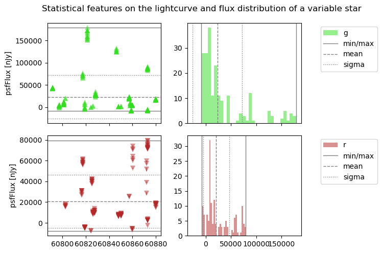

```python
fig, ax = plt.subplots(2, 2, figsize=(8, 5), sharex='col')
s_lw = [1, 1, 1, 1, 1]
s_ls = ['solid', 'solid', 'dashed', 'dotted', 'dotted']
s_lb = ['min/max', None, 'mean', 'sigma', None]
for f, filt in enumerate(['g', 'r']):
    tx = np.where(star_diaSources['band'] == filt)[0]
    ax[f, 0].errorbar(star_diaSources['midpointMjdTai'][tx], star_diaSources['psfFlux'][tx],
                      yerr=star_diaSources['psfFluxErr'][tx], fmt=f_sym[filt],
                      ms=7, alpha=0.5, mew=0, color=f_col[filt], label=filt + ', star')
    ax[f, 1].hist(star_diaSources['psfFlux'][tx], bins=30,
                  alpha=0.5, color=f_col[filt], label=filt)
    s_vl = [star_diaObject[filt + '_psfFluxMin'], star_diaObject[filt + '_psfFluxMax'],
            star_diaObject[filt + '_psfFluxMean'],
            star_diaObject[filt + '_psfFluxMean'] - star_diaObject[filt + '_psfFluxSigma'],
            star_diaObject[filt + '_psfFluxMean'] + star_diaObject[filt + '_psfFluxSigma']]
    for s in range(len(s_vl)):
        ax[f, 0].axhline(s_vl[s], lw=s_lw[s], ls=s_ls[s], color='grey', label=s_lb[s])
        ax[f, 1].axvline(s_vl[s], lw=s_lw[s], ls=s_ls[s], color='grey', label=s_lb[s])
    ax[f, 1].legend(bbox_to_anchor=(1.7, 1), loc='upper right')
    ax[f, 0].set_ylabel('psfFlux [nJy]')
del tx, s_vl, s_lb
plt.suptitle('Statistical features on the lightcurve and flux distribution of a variable star')
plt.tight_layout()
plt.show()
```

> **Figure 2:** The $g$- (top) and $r$-band (bottom) light curves (left) and flux distributions (right) for the variable star, with the minimum and maximum (solid), and mean and standard deviation (dashed and dotted) statistics overplotted as grey lines.

### 3.6. Max slope

The `psfFluxMaxSlope` is the maximum "instantaneous" slope, or the maximum ratio of the series of time-ordered values of $\Delta f / \Delta t$.

```python
for f, filt in enumerate(use_filters):
    diao_mm = float(star_diaObject[filt + '_psfFluxMaxSlope'])
    tx = np.where((star_diaSources['band'] == filt)
                  & (~np.isnan(star_diaSources['psfFlux']))
                  & (~np.isnan(star_diaSources['psfFluxErr']))
                  & (~np.isnan(star_diaSources['midpointMjdTai'])))[0]
    sx = np.argsort(star_diaSources['midpointMjdTai'][tx])

    dias_mm = (np.diff(star_diaSources['psfFlux'][tx[sx]])
               / np.diff(star_diaSources['midpointMjdTai'][tx[sx]])).max()
    print(filt + 'band       diaObject   diaSource')
    print('Max Slope  %10.0f  %10.0f ' % (diao_mm, dias_mm))
    if f == 0:
        print(' ')
    del diao_mm, tx, sx, dias_mm
```

```
gband       diaObject   diaSource
Max Slope    11886967    11887349

rband       diaObject   diaSource
Max Slope     6746364     6746335
```

> **Notice:** For the linear fits, the re-derived parameters from the `DiaSource` table are not an exact match to the parameters stored in the `DiaObject` table. It is unclear why as the code above uses the same calculation as in the [diaCalculationPlugin](https://github.com/lsst/meas_base/blob/main/python/lsst/meas/base/diaCalculationPlugins.py) for class `LinearFitDiaPsfFlux`.

### 3.7. Science flux features

The `<f>_scienceFluxMean` is the weighted mean of the forced PSF fluxes measured on the science (direct) images. The `<f>_scienceFluxMeanErr` is the error on the weighted mean flux. Both features use the same formulae as quoted in Section 3.4.

Demonstrate how to derive these statistics for the `scienceFlux`.

```python
for f, filt in enumerate(use_filters):
    diao_sci_mean = float(star_diaObject[filt + '_scienceFluxMean'])
    diao_sci_meane = float(star_diaObject[filt + '_scienceFluxMeanErr'])
    tx = np.where(star_diaSources['band'] == filt)[0]
    dias_sci_w = 1.0/(star_diaSources['scienceFluxErr'][tx]**2)
    dias_sci_wmean = np.sum(star_diaSources['scienceFlux'][tx] * dias_sci_w) / np.sum(dias_sci_w)
    dias_sci_meane = 1.0 / np.sqrt(np.sum(dias_sci_w))
    print(filt + '-band    diaObject    diaSource')
    print('Mean     %10.0f   %10.0f ' % (diao_sci_mean, dias_sci_wmean))
    print('MeanErr  %10.2f   %10.2f ' % (diao_sci_meane, dias_sci_meane))
    if f == 0:
        print(' ')
    del diao_sci_mean, diao_sci_meane
    del tx, dias_sci_w, dias_sci_wmean, dias_sci_meane
```

```
g-band    diaObject    diaSource
Mean         120780       120780
MeanErr       24.19        24.19

r-band    diaObject    diaSource
Mean         153782       153782
MeanErr       36.12        36.12
```